# Trabalho 2 — Da tabela ao gráfico

Antonio Carlos de Oliveira Silva

05/11/2026

# 1. Tabela de dados

```r
dados <- read_csv("dados/gapminder/gapminder.csv", show_col_types = FALSE) |>
  mutate(
    pais = factor(pais),
    continente = factor(continente),
    ano = as.integer(ano),
    expectativa_vida = as.numeric(expectativa_vida),
    populacao = as.numeric(populacao),
    pib_per_capita = as.numeric(pib_per_capita)
  )

glimpse(dados)
```

```
## Rows: 1,704
## Columns: 6
## $ pais             <fct> "Afghanistan", "Afghanistan", "Afghanistan", "Afghanistan", "Afghanistan", "Afghani…
## $ continente       <fct> Asia, Asia, Asia, Asia, Asia, Asia, Asia, Asia, Asia, Asia, Asia, Asia, Europe, Eur…
## $ ano              <int> 1952, 1957, 1962, 1967, 1972, 1977, 1982, 1987, 1992, 1997, 2002, 2007, 1952, 1957,…
## $ expectativa_vida <dbl> 28.801, 30.332, 31.997, 34.020, 36.088, 38.438, 39.854, 40.822, 41.674, 41.763, 42.…
## $ populacao        <dbl> 8425333, 9240934, 10267083, 11537966, 13079460, 14880372, 12881816, 13867957, 16317…
## $ pib_per_capita   <dbl> 779.4453, 820.8530, 853.1007, 836.1971, 739.9811, 786.1134, 978.0114, 852.3959, 649…
```

Cada linha representa a observação de um país em um ano (1952–2007, em intervalos de cinco anos); há 1.704 casos e seis variáveis. `pais` é nominal (N), `continente` é nominal (N), `ano` é ordinal temporal (Otemp), e `expectativa_vida` (anos), `populacao` (habitantes) e `pib_per_capita` (dólares internacionais ajustados) são quantitativas (Q). A chave composta `pais` + `ano` determina as três medidas quantitativas: `pais, ano → expectativa_vida, populacao, pib_per_capita`; cada país também determina seu continente: `pais → continente`. `pais` sozinho não determina as medidas porque há observações repetidas do mesmo país ao longo do tempo.

# 2. Transformações

**Transformação 1 — valores → valores derivados.** Calculo o logaritmo decimal da população para trabalhar com sua grande amplitude entre países.

```r
dados_log <- dados |>
  mutate(log10_populacao = log10(populacao))
dados_log |>
  select(pais, ano, populacao, log10_populacao) |>
  slice_head(n = 6)
```

```
## # A tibble: 6 × 4
##   pais          ano populacao log10_populacao
##   <fct>       <int>     <dbl>           <dbl>
## 1 Afghanistan  1952   8425333            6.93
## 2 Afghanistan  1957   9240934            6.97
## 3 Afghanistan  1962  10267083            7.01
## 4 Afghanistan  1967  11537966            7.06
## 5 Afghanistan  1972  13079460            7.12
## 6 Afghanistan  1977  14880372            7.17
```

**Transformação 2 — estrutura → estrutura derivada.** Reorganizo as observações de países e anos em uma tabela larga, com uma coluna de expectativa de vida por ano.

```r
expectativa_larga <- dados |>
  select(pais, ano, expectativa_vida) |>
  pivot_wider(names_from = ano, values_from = expectativa_vida)
glimpse(expectativa_larga)
```

```
## Rows: 142
## Columns: 13
## $ pais   <fct> "Afghanistan", "Albania", "Algeria", "Angola", "Argentina", "Australia", "Austria", "Bahrain"…
## $ `1952` <dbl> 28.801, 55.230, 43.077, 30.015, 62.485, 69.120, 66.800, 50.939, 37.484, 68.000, 38.223, 40.41…
## $ `1957` <dbl> 30.33200, 59.28000, 45.68500, 31.99900, 64.39900, 70.33000, 67.48000, 53.83200, 39.34800, 69.…
## $ `1962` <dbl> 31.99700, 64.82000, 48.30300, 34.00000, 65.14200, 70.93000, 69.54000, 56.92300, 41.21600, 70.…
## $ `1967` <dbl> 34.02000, 66.22000, 51.40700, 35.98500, 65.63400, 71.10000, 70.14000, 59.92300, 43.45300, 70.…
## $ `1972` <dbl> 36.08800, 67.69000, 54.51800, 37.92800, 67.06500, 71.93000, 70.63000, 63.30000, 45.25200, 71.…
## $ `1977` <dbl> 38.43800, 68.93000, 58.01400, 39.48300, 68.48100, 73.49000, 72.17000, 65.59300, 46.92300, 72.…
## $ `1982` <dbl> 39.854, 70.420, 61.368, 39.942, 69.942, 74.740, 73.180, 69.052, 50.009, 73.930, 50.904, 53.85…
## $ `1987` <dbl> 40.822, 72.000, 65.799, 39.906, 70.774, 76.320, 74.940, 70.750, 52.819, 75.350, 52.337, 57.25…
## $ `1992` <dbl> 41.674, 71.581, 67.744, 40.647, 71.868, 77.560, 76.040, 72.601, 56.018, 76.460, 53.919, 59.95…
## $ `1997` <dbl> 41.763, 72.950, 69.152, 40.963, 73.275, 78.830, 77.510, 73.925, 59.412, 77.530, 54.777, 62.05…
## $ `2002` <dbl> 42.129, 75.651, 70.994, 41.003, 74.340, 80.370, 78.980, 74.795, 62.013, 78.320, 54.406, 63.88…
## $ `2007` <dbl> 43.828, 76.423, 72.301, 42.731, 75.320, 81.235, 79.829, 75.635, 64.062, 79.441, 56.728, 65.55…
```

**Transformação 3 — Q → O.** Uso `cut()` para converter a expectativa de vida quantitativa em uma variável ordinal de faixas, preservando sua ordem natural.

```r
faixas_expectativa <- cut(
  dados$expectativa_vida,
  breaks = c(-Inf, 50, 60, 70, 80, Inf),
  labels = c("<50", "50–60", "60–70", "70–80", "80–90"),
  right = FALSE,
  ordered_result = TRUE
)
table(faixas_expectativa)
```

```
## faixas_expectativa
##   <50 50–60 60–70 70–80 80–90
##   491   336   383   472    22
```

# 3. Gráficos

## 3.1 Gráfico 1 — População e expectativa de vida em 2007

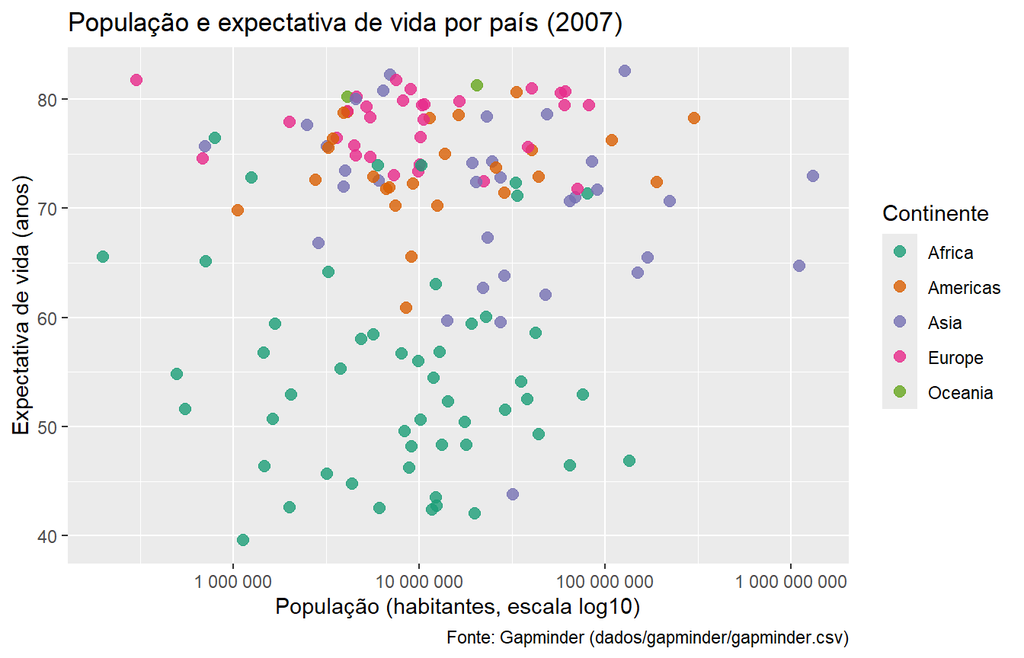

```r
dados |>
  filter(ano == 2007) |>
  ggplot(aes(x = populacao, y = expectativa_vida, colour = continente)) +
  geom_point(alpha = 0.8, size = 2.5) +
  scale_x_log10(labels = scales::label_number()) +
  scale_colour_brewer(palette = "Dark2") +
  labs(title = "População e expectativa de vida por país (2007)",
       x = "População (habitantes, escala log10)", y = "Expectativa de vida (anos)",
       colour = "Continente", caption = "Fonte: Gapminder (dados/gapminder/gapminder.csv)")
```

**Tabela de mapeamento**

| Variável | Tipo (N / O / Otemp / Q / Qtemp) | Propriedade gráfica ou espacial |
| --- | --- | --- |
| `populacao` | Q | posição horizontal (x), escala logarítmica |
| `expectativa_vida` | Q | posição vertical (y) |
| `continente` | N | matiz (cor), escala discreta |

**Justificativa:** A posição em x e y usa duas variáveis quantitativas, mapeamento expressivo para investigar associação entre população e expectativa de vida. A população tem amplitude muito grande, por isso a escala logarítmica em x distribui melhor os países sem alterar sua ordem. O continente é nominal e recebe cores distintas, com paleta discreta; não se sugere uma ordem entre categorias. Pontos são marcas adequadas para observações individuais.

## 3.2 Gráfico 2 — Expectativa média por continente

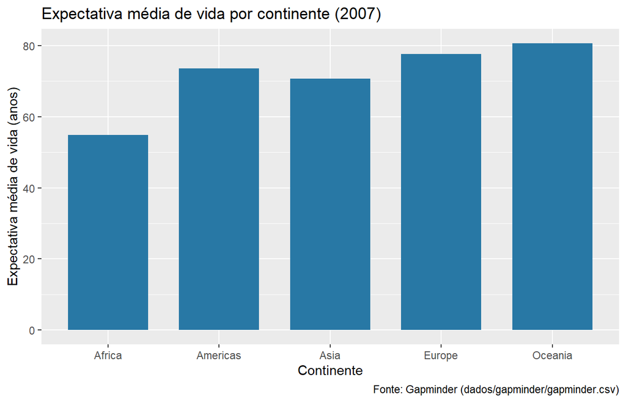

```r
dados |>
  filter(ano == 2007) |>
  group_by(continente) |>
  summarise(media_vida = mean(expectativa_vida), .groups = "drop") |>
  ggplot(aes(x = continente, y = media_vida)) +
  geom_col(fill = "#2878A5", width = 0.72) +
  labs(title = "Expectativa média de vida por continente (2007)",
       x = "Continente", y = "Expectativa média de vida (anos)",
       caption = "Fonte: Gapminder (dados/gapminder/gapminder.csv)")
```

**Tabela de mapeamento**

| Variável | Tipo (N / O / Otemp / Q / Qtemp) | Propriedade gráfica ou espacial |
| --- | --- | --- |
| `continente` | N | posição horizontal (x), categorias discretas |
| `media_vida` (derivada) | Q | posição vertical (y), comprimento da barra |

**Justificativa:** A média é quantitativa e seu comprimento em uma barra alinhada a uma base comum permite comparar valores com precisão, uma propriedade efetiva para magnitudes. O continente é nominal, portanto ocupa posições categóricas separadas, sem ordenação numérica implícita. A cor única evita acrescentar uma codificação redundante que não representa uma variável adicional.

## 3.3 Gráfico 3 — Distribuição entre países

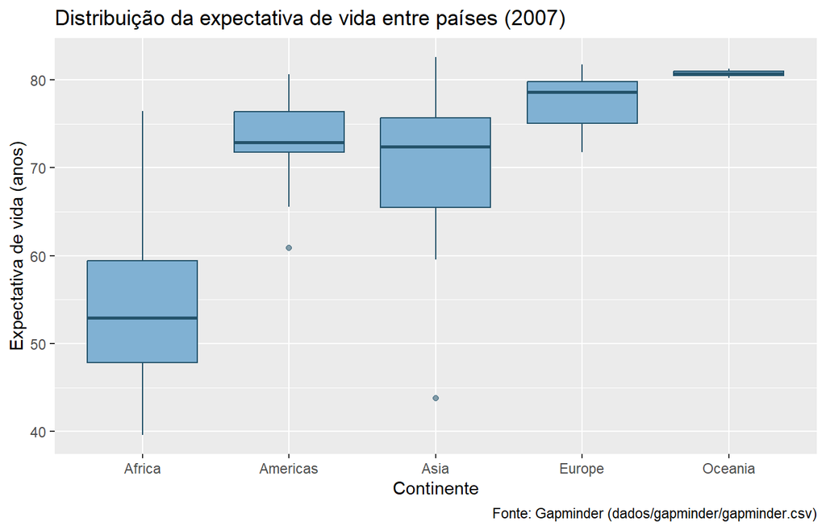

```r
dados |>
  filter(ano == 2007) |>
  ggplot(aes(x = continente, y = expectativa_vida)) +
  geom_boxplot(fill = "#80B1D3", colour = "#24536B", outlier.alpha = 0.55) +
  labs(title = "Distribuição da expectativa de vida entre países (2007)",
       x = "Continente", y = "Expectativa de vida (anos)",
       caption = "Fonte: Gapminder (dados/gapminder/gapminder.csv)")
```

**Tabela de mapeamento**

| Variável | Tipo (N / O / Otemp / Q / Qtemp) | Propriedade gráfica ou espacial |
| --- | --- | --- |
| `continente` | N | posição horizontal (x), categorias discretas |
| `expectativa_vida` | Q | posição vertical (y), distribuição resumida por caixa e bigodes |

**Justificativa:** O boxplot mostra a distribuição de uma variável quantitativa em grupos nominais: mediana, quartis, dispersão e possíveis valores extremos. A posição vertical usa uma escala comum para todos os continentes e facilita comparar as distribuições. A marca de caixa resume muitos países sem depender de cor para distinguir os grupos.

## 3.4 Gráfico 4 — Forma da distribuição

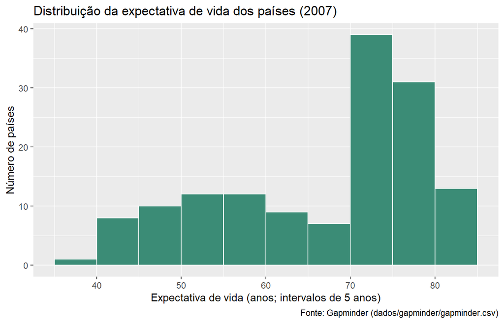

```r
dados |>
  filter(ano == 2007) |>
  ggplot(aes(x = expectativa_vida)) +
  geom_histogram(binwidth = 5, boundary = 0, fill = "#3B8C76", colour = "white") +
  labs(title = "Distribuição da expectativa de vida dos países (2007)",
       x = "Expectativa de vida (anos; intervalos de 5 anos)", y = "Número de países",
       caption = "Fonte: Gapminder (dados/gapminder/gapminder.csv)")
```

**Tabela de mapeamento**

| Variável | Tipo (N / O / Otemp / Q / Qtemp) | Propriedade gráfica ou espacial |
| --- | --- | --- |
| `expectativa_vida` | Q | posição horizontal agrupada em intervalos; contagem determina a altura |

**Justificativa:** O histograma usa intervalos contíguos para uma variável quantitativa e mostra a forma da distribuição entre países. A posição horizontal preserva a ordem e a proximidade dos valores; a altura representa a contagem de países em cada intervalo. Intervalos de cinco anos dão uma visão geral legível sem codificações de cor desnecessárias.

# 4. Makeover

Escolhi o gráfico `ruim_05.png`, que codifica continentes como números inteiros e usa uma escala contínua de cor.

**Diagnóstico:** O gráfico atribui números à variável nominal `continente` e mapeia esses códigos em uma escala contínua de cor, afirmando uma ordem e distâncias entre continentes que a tabela não contém.

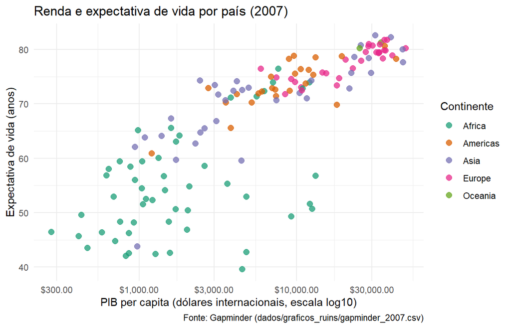

```r
dados_makeover <- read_csv("dados/graficos_ruins/gapminder_2007.csv", show_col_types = FALSE) |>
  mutate(continente = factor(continente,
    levels = c("Africa", "Americas", "Asia", "Europe", "Oceania")))

refeito <- ggplot(dados_makeover,
                  aes(x = pib_per_capita, y = expectativa_vida, colour = continente)) +
  geom_point(alpha = 0.75, size = 2.5) +
  scale_x_log10(labels = scales::label_dollar()) +
  scale_colour_brewer(palette = "Dark2", drop = FALSE) +
  labs(title = "Renda e expectativa de vida por país (2007)",
       x = "PIB per capita (dólares internacionais, escala log10)",
       y = "Expectativa de vida (anos)", colour = "Continente",
       caption = "Fonte: Gapminder (dados/graficos_ruins/gapminder_2007.csv)") +
  theme_minimal()

refeito
```

**O que foi corrigido:**

1. `continente` é convertido em fator e mapeado a uma escala discreta de matizes. Isso respeita seu tipo nominal e remove a falsa ordem que uma escala contínua sugere (expressividade).
2. Os pontos ficam parcialmente transparentes (`alpha = 0.75`), reduzindo a obstrução quando países se sobrepõem e permitindo perceber concentrações sem trocar a marca de ponto (efetividade). O rótulo do eixo também explicita a unidade monetária e a escala logarítmica.

# Fontes consultadas

Kit de dados do curso (`README.md` de `dados/gapminder` e `dados/graficos_ruins`) e modelo/enunciado do Trabalho 2. Código elaborado com auxílio de inteligência artificial generativa (OpenAI, ChatGPT/Codex).